**Nome:** Riccardo  
**Cognome:** Confalonieri  
**Numero matricola:** 830404  
**E-mail:** r.confalonieri5@campus.unimib.it  
**A.A.** 2021-2022

# **Digital Signal and Image Management - Assignment 4**

**Master's Degree in Data Science (A.Y. 2021/2022)**  
**University of Milano - Bicocca**

Simone Bianco, Marco Buzzelli

## Descrizione

Implementare una rete neurale per la classificazione d'immagini che abbia la seguente architettura:

1. layer di convoluzione 2D con 32 filtri 3x3
2. relu
3. layer di maxpooling (2D) con filtri 2x2
4. flattening
5. fully connected che mappa a 128 neuroni
6. relu
7. fully connected alla dimensione del problema

In particolare si chiede di valutare la classificazione sia per il dataset MNIST che per il dataset CIFAR10.

## Import packages

```python
# importo keras da tensorflow
from tensorflow import keras

# per visualizzare/manipolare i dati
import random
import numpy as np
import matplotlib.pyplot as plt
import seaborn as sns

# per ulteriore splitting
from sklearn.model_selection import train_test_split

# drive per esportare il file in .html
from google.colab import drive

# per valutare le performance del modello
from sklearn.metrics import confusion_matrix
from sklearn.metrics import accuracy_score
from sklearn.metrics import classification_report
from sklearn.metrics import precision_recall_fscore_support
```

## MNIST dataset

Carico il dataset MNIST e visualizzo alcune informazioni di base riguardanti il dataset.

```python
# carico i dati
(x_train, y_train), (x_test, y_test) = keras.datasets.mnist.load_data()
```

```python
# informazioni di base sul dataset
print('Tipo delle immagini:', type(x_train))
print('Numero di esempi di training:', x_train.shape[0])
print('Numero di label per il training:', y_train.shape[0])
print("Dimensione dell'immagine: " + str(x_train.shape[1]) + "x" + str(x_train.shape[2]))
print("Range di valori dell'immagine ["+ str(x_train.min()) + ","
      + str(x_train.max()) + "]")
print("Tipo dei valori dell'immagine: ", type(x_train[0,10,12]))
print('Numero di esempi di test:', x_test.shape[0])
```

```
Tipo delle immagini: <class 'numpy.ndarray'>
Numero di esempi di training: 60000
Numero di label per il training: 60000
Dimensione dell'immagine: 28x28
Range di valori dell'immagine [0,255]
Tipo dei valori dell'immagine:  <class 'numpy.uint8'>
Numero di esempi di test: 10000
```

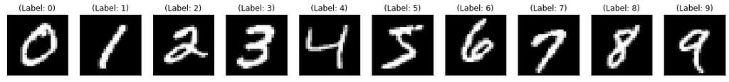

```python
# Base idea = https://stackoverflow.com/questions/53837545/plotting-mnist-samples

plt.figure(figsize=(20, 4))
# visualizzo tutte e 10 le classi presenti nel dataset
for i in range(10):
  idx = np.argwhere(y_train == i)[0,0]
  ax = plt.subplot(2, 10, i + 1)
  # colormap = gray for better visualization
  plt.imshow(x_train[idx], cmap = "gray")
  # add label title
  plt.title("(Label: " + str(y_train[idx]) + ")")
  # remove axis from visualization
  ax.get_xaxis().set_visible(False)
  ax.get_yaxis().set_visible(False)
```

### Check Y label

Verifico che i valori delle label siano coerenti e quindi compresi nel range $[0,9]$. Verifico inoltre che non ci sia un forte sbilanciamento tra le varie classi.

```python
print("Le label assumono i seguenti valori:", set(y_train))

# get the total number of labels
n_labels = len(set(y_train))
```

```
Le label assumono i seguenti valori: {0, 1, 2, 3, 4, 5, 6, 7, 8, 9}
```

Le classi risultano essere nel range corretto, effettuerò però la conversione in one-hot encoding invece di mantenere dei numeri interi.

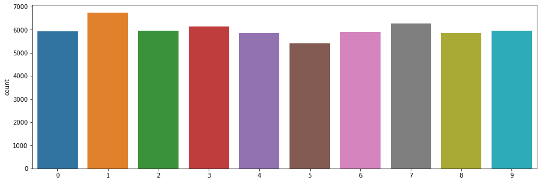

```python
plt.figure(figsize = (15,5))
sns.countplot(y_train)
plt.show()
```

Il grafico non evidenzia sbilanciamenti notevoli tra i diversi numeri.

### Preprocessing

In questa sezione mi occuperò di gestire le problematiche evidenziate dall'analisi del dataset in modo da ottenere un ''nuovo'' dataset pronto per essere passato al modello neurale. In particolare si effettuaranno i seguenti preprocessing:

1. Conversione dei valori in float e nell'intervallo $[0,1]$
2. Modifica della shape del dataset da due a tre dimensioni per renderlo coerente con quanto servirà nei layers del modello.
3. One-hot encoding delle label (non obbligatorio per il modello).

In particolare tutte queste operazioni verranno effettuate sia sul training che sul test set, in modo da effettuare gli stesssi passaggi ed avere un test set coerente ed utilizzabile una volta trainato il modello.  
Inoltre si procederà a *splittare il dataset* di training per ottenere una piccola porzione di validation utile per valutare i modelli creati. In questo modo utilizzerò il test set già a disposizione come se non conoscessi le corrispondenti label, così da poter provare ad effettuare una predizione e verificare i risultati in maniera indipendente (il validation è comunque utilizzato in fase di training e quindi potrebbe avere un'accuratezza diversa da quella reale su nuovi dati).

```python
# riscalo i valori in float in [0,1]
x_train = x_train.astype('float32')/255.0
x_test = x_test.astype('float32')/255.0

# verifico il risultato
print("Tipo dei valori dell'immagine: ", type(x_train[0,10,12]))
```

```
Tipo dei valori dell'immagine:  <class 'numpy.float32'>
```

```python
# reshaping dell'immagine

# aggiungo una dimensione fittizia, è necessario per i layer convoluzionali che
# vogliono 4 dimensioni in input (batch x altezza x larghezza x Ncanali)
x_train = np.expand_dims(x_train, axis = -1)
x_test= np.expand_dims(x_test, axis = -1)

# verifico il risultato
print("Dimensione dell'immagine: " + str(x_train.shape[1]) + "x" +
      str(x_train.shape[2]) + "x" + str(x_train.shape[3]))
```

```
Dimensione dell'immagine: 28x28x1
```

```python
# one hot encoding delle label
yc_train = keras.utils.to_categorical(y_train, n_labels)
yc_test = keras.utils.to_categorical(y_test, n_labels)

# visualizzo il risultato
print(y_train[0], "to ->", yc_train[0])
```

```
5 to -> [0. 0. 0. 0. 0. 1. 0. 0. 0. 0.]
```

```python
# effettuo lo splitting del training set per ottenere una parte di validation
x_train, x_val, y_train, y_val = train_test_split(x_train, yc_train,
                                                  test_size = 0.1,
                                                  # per replicabilità
                                                  random_state=99)
```

### Neural network

Definisco la neural network per il task di classificazione seguendo le specifiche date per l'assignment. Riporto in questa sezione anche due funzioni utili che permettono di plottare l'andamento della storia del traning e di calcolare delle metriche sulle previsioni e visualizzarle. Inoltre dato che il modello è standard per le richieste dell'assignment creo una funzione che dato l'input e alcuni parametri definisce e restiuisce il modello.

```python
# Funzione che definisce il modello secondo i parametri
def create_neural_model(x, opt_func, dropout_rate = None):
  # modello sequenziale
  model = keras.Sequential()

  # Layer di input
  model.add(keras.Input(x.shape[1:]))
  # layer di convoluzione 2D con 32 filtri 3x3
  model.add(keras.layers.Conv2D(filters=32, kernel_size=(3, 3)))
  # relu (potevo includerla direttamente nel layer precedente col parametro activation)
  model.add(keras.layers.Activation(keras.activations.relu))
  # layer di maxpooling (2D) con filtri 2x2
  model.add(keras.layers.MaxPool2D(pool_size=(2, 2), strides=2))
  # flattening -> perdo la dimensione spaziale delle immagini
  model.add(keras.layers.Flatten())
  # fully connected che mappa a 128 neuroni (diminuzione della dimensione)
  model.add(keras.layers.Dense(128))
  # relu
  model.add(keras.layers.Activation(keras.activations.relu))

  # se definito aggiungo il layer di dropout con il rate specifico
  if dropout_rate:
    model.add(keras.layers.Dropout(dropout_rate))
  # ultimo layer che permette di predire la classe di appartenenza
  model.add(keras.layers.Dense(n_labels, activation='softmax'))

  # ottimizzatore della rete neurale
  model.compile(optimizer = opt_func, loss = "categorical_crossentropy",
                metrics = ["accuracy"])

  return model
```

```python
# Funzione che visualizza la storia di training del modello
def plot_history(network_history):
    plt.figure(figsize = (10, 6))
    plt.xlabel('Epochs')
    plt.ylabel('Loss')
    plt.xticks(np.arange(len(network_history.epoch)), np.arange(1, len(network_history.epoch)+1))
    plt.title('model loss')
    plt.plot(network_history.history['loss'], marker='.')
    plt.plot(network_history.history['val_loss'], marker='.')
    plt.legend(['Training', 'Validation'])

    plt.figure(figsize = (10, 6))
    plt.xlabel('Epochs')
    plt.ylabel('Accuracy')
    plt.xticks(np.arange(len(network_history.epoch)), np.arange(1, len(network_history.epoch)+1))
    plt.title('model accuracy')
    plt.plot(network_history.history['accuracy'], marker='.')
    plt.plot(network_history.history['val_accuracy'], marker='.')
    plt.legend(['Training', 'Validation'], loc='lower right')
    plt.show()
```

```python
def evaluate_predition_ffnn(model, x_test, y_test):
  # Funzione che permette di computare e visualizzare graficamente alcune
  # metriche di accuratezza sulle previsioni

  # predico le nuove label basandomi solo sul test set
  y_hat = model.predict(x_test)
  # Assegno alla predizione la label con maggior score
  y_hat = y_hat.argmax(axis=1)

  # Dato che ho effettuato one-hot encoding riporto le y_test a valori interi per il confronto
  y_test = y_test.argmax(axis = 1)

  # calcolo confusion matrix
  cm = confusion_matrix(y_test, y_hat)

  # calcolo e visualizzo il classification report
  cl = classification_report(y_test, y_hat, output_dict=True)
  print('\nClassification Report\n', classification_report(y_test, y_hat))

  # plot beautiful confusion matrix
  ax = plt.subplot()
  sns.heatmap(cm, annot=True, fmt='g', cmap="YlGnBu");

  ax.set_xlabel('True labels'); ax.set_ylabel('Predicted labels');
  ax.set_title('Confusion Matrix');
  ax.xaxis.set_ticklabels(range(0,10));
  ax.yaxis.set_ticklabels(range(0,10));

  return y_hat, cl
```

```python
# definisco il modello
model_mnist = create_neural_model(x_train, "sgd")

# visualizzo il modello
print(model_mnist.summary())
```

```
Model: "sequential_8"
_________________________________________________________________
 Layer (type)                Output Shape              Param #
=================================================================
 conv2d_8 (Conv2D)           (None, 26, 26, 32)        320

 activation_16 (Activation)  (None, 26, 26, 32)        0

 max_pooling2d_8 (MaxPooling  (None, 13, 13, 32)       0
 2D)

 flatten_8 (Flatten)         (None, 5408)              0

 dense_16 (Dense)            (None, 128)               692352

 activation_17 (Activation)  (None, 128)               0

 dense_17 (Dense)            (None, 10)                1290

=================================================================
Total params: 693,962
Trainable params: 693,962
Non-trainable params: 0
_________________________________________________________________
None
```

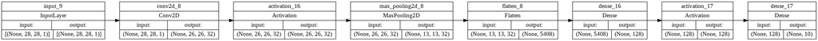

```python
# visualizzo il modello appena definito
keras.utils.plot_model(model_mnist, show_shapes=True, rankdir="LR")
```

Traino il modello appena definito, utilizzo anche lo shuffling dei dati anche se il dataset sembra già contenere le immagini dei numeri in maniera randomica.

```python
# traino il modello sui dati + validation set
history_mnist = model_mnist.fit(x_train, y_train, epochs = 40,
                                batch_size = 128, verbose = 1,
                                shuffle = True,
                                validation_data=(x_val, y_val))
```

```python
print("Numero di epoche totali:", len(history_mnist.epoch))
print("Accuracy training:", history_mnist.history['accuracy'][-1])
print("Accuracy validation:", history_mnist.history['val_accuracy'][-1])
print("Loss training set:", history_mnist.history['loss'][-1])
print("Loss validation set:", history_mnist.history['val_loss'][-1])
```

```
Numero di epoche totali: 40
Accuracy training: 0.9844074249267578
Accuracy validation: 0.9764999747276306
Loss training set: 0.05257550999522209
Loss validation set: 0.08117379993200302
```

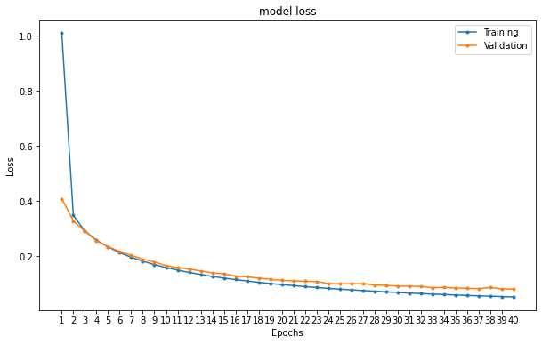

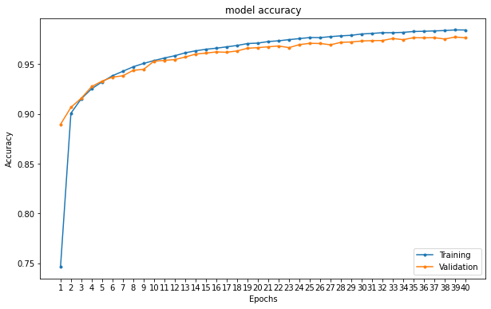

```python
# visualizzo la storia del training
plot_history(history_mnist)
```

Il modello proposto sembra essere soggetto ad un leggero overfitting a partire circa dall'epoca $20$, inoltre sembra richiede molte epoche per arrivare a buone performance di accuratezza quindi l'apprendimento sembra essere lento.  
Per provare a risolvere queste problematiche provo a mettere in atto le seguenti tecniche:

1. Aggiunta di un early stopping per fermare automaticamente la funzione di training qualora si verifichi un overfitting o la rete non stia più apprendendo o addirittura peggiorando.
2. Cambio di funzione di ottimizzazione per provare a diminuire il numero di epoche necessarie.
3. Utilizzo della tecnica di dropout sull'ultimo layer fully connected per provare a mitigare l'overfitting.

#### Second neural network

Provo ad utilizzare **adam** come funzione di ottimizzazione con l'aggiunta delle tecniche di **dropout** ed **early stopping**.

```python
# definisco il modello
model_mnist_2 = create_neural_model(x_train, "adam", 0.5)

# visualizzo il modello
print(model_mnist_2.summary())
```

```
Model: "sequential_7"
_________________________________________________________________
 Layer (type)                Output Shape              Param #
=================================================================
 conv2d_7 (Conv2D)           (None, 26, 26, 32)        320

 activation_14 (Activation)  (None, 26, 26, 32)        0

 max_pooling2d_7 (MaxPooling  (None, 13, 13, 32)       0
 2D)

 flatten_7 (Flatten)         (None, 5408)              0

 dense_14 (Dense)            (None, 128)               692352

 activation_15 (Activation)  (None, 128)               0

 dropout_7 (Dropout)         (None, 128)               0

 dense_15 (Dense)            (None, 10)                1290

=================================================================
Total params: 693,962
Trainable params: 693,962
Non-trainable params: 0
_________________________________________________________________
None
```

```python
# Aggiungo un early_stopping per evitare possibili overfitting, in questo modo posso
# aumentare il numero di epoche di training. Descrizione parametri:
# restore_best_weights=True: mi assicura che vengano usati i pesi migliori trovati fino a quel momento
# monitor: mi indica che metrica viene utilizzata per decidere se fermare il training
# min_delta: minima variazione richiesta per continuare a trainare
# patience: quante epoche andare avanti anche se min_delta non viene rispettata
early_stopping = keras.callbacks.EarlyStopping(monitor='val_loss', verbose=1,
                                               patience=2, min_delta = 0.001,
                                               mode='min',
                                               restore_best_weights=True)

# traino il modello sui dati + validation set
history_mnist_2 = model_mnist_2.fit(x_train, y_train, epochs = 40,
                                    batch_size = 128, verbose = 1,
                                    shuffle = True,
                                    validation_data=(x_val, y_val),
                                    callbacks=[early_stopping])
```

```
Epoch 00008: early stopping
```

In questo caso l'early stopping è stato utilizzato, il training è stato infatti fermato dopo $8$ epoche su $40$. Inoltre sono stati ripristinati i pesi trovati all'epoca $6$. Visualizzo dunque alcune di queste informazioni dalle variabili di training.

```python
print("Numero di epoche totali:", (early_stopping.stopped_epoch+1))
print("Epoca migliore (weights restored):", (early_stopping.best_epoch+1))
print("Accuracy training set all'epoca " + str(early_stopping.best_epoch+1) + ": "
      + str(history_mnist_2.history['accuracy'][early_stopping.best_epoch]))
print("Accuracy validation set all'epoca " + str(early_stopping.best_epoch+1) + ": "
      + str(history_mnist_2.history['val_accuracy'][early_stopping.best_epoch]))
print("Loss training set all'epoca " + str(early_stopping.best_epoch+1) + ": "
      + str(history_mnist_2.history['loss'][early_stopping.best_epoch]))
print("Loss validation set all'epoca " + str(early_stopping.best_epoch+1) + ": "
      + str(history_mnist_2.history['val_loss'][early_stopping.best_epoch]))
```

```
Numero di epoche totali: 8
Epoca migliore (weights restored): 6
Accuracy training set all'epoca 6: 0.9831666946411133
Accuracy validation set all'epoca 6: 0.9865000247955322
Loss training set all'epoca 6: 0.05624934285879135
Loss validation set all'epoca 6: 0.04975716769695282
```

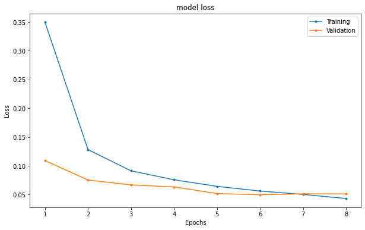

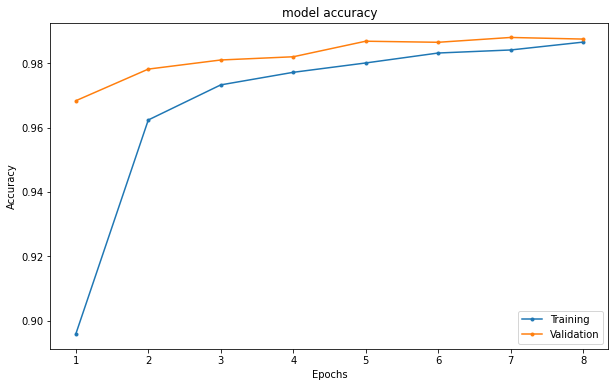

```python
# visualizzo la storia del training
plot_history(history_mnist_2)
```

Il cambio di funzione di ottimizzazione ha sicuramente *migliorato il numero di epoche richieste*, già dall'inizio infatti otteniamo valori di performance molto simili a quelli finali ottenuti con 'stochastic gradient descent (SGD)'. Inoltre anche *l'early stopping e il dropout sono stati fondamentali*, nello specifico il training è stato fermato dopo due epoche consecutive in cui i valori di loss e validation hanno iniziato a divergere e quindi a segnalare un probabile overfitting. In particolare, nelle due epoche che hanno portato allo stop, il livello di loss era crescente segnalando un peggioramento mentre l'accuracy era leggeremente migliorata ma non in maniera significativa. Infine come si può notare dai grafici fino allo stop la rete non sembra essere soggetta ad overfitting.  
Per migliorare ulteriormente la rete si potrebbe provare a cambiare il numero di layer utilizzati e/o la loro configurazione.. Ho preferito però non modificare la struttura della rete per rispettare il più possibile le richieste dell'assignment, tuttavia il numero di parametri utilizzati per risolvere questo task è molto alto e già con reti più semplici si riesce ad aggiungere lo stesso livello di performance.  
Durante la fase di implementazione si sono testate anche altre funzioni di ottimizzazione come 'adadelta' che miglioravano la possibile problematica di overfitting ma richiedevano molte più epoche per raggiungere performance altrettanto buone. La configurazione proposta nel notebook sembra dunque essere la *configurazione migliore trovata* per questo tipo di modello.

### MINST prediction

Dato che prima avevo appositamente riservato il test set per provare a fare delle predizioni su dati mai visti provo ad utilizzare il secondo modello fittato che sembrava essere il migliore e verificarne nuovamente le performance.

```
Classification Report
               precision    recall  f1-score   support

           0       0.98      0.99      0.99       980
           1       0.99      0.99      0.99      1135
           2       0.98      0.99      0.99      1032
           3       0.99      0.99      0.99      1010
           4       0.99      0.99      0.99       982
           5       0.98      0.99      0.98       892
           6       0.98      0.98      0.98       958
           7       0.98      0.99      0.98      1028
           8       0.99      0.97      0.98       974
           9       0.99      0.97      0.98      1009

    accuracy                           0.99     10000
   macro avg       0.99      0.99      0.99     10000
weighted avg       0.99      0.99      0.99     10000
```

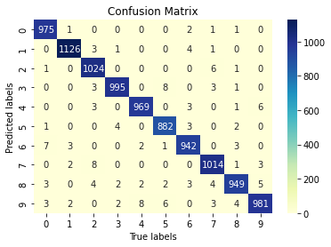

```python
# valuto le performance del modello
_,_ = evaluate_predition_ffnn(model_mnist_2, x_test, yc_test)
```

Le performance risultano essere molto buone su tutte le label. Si segnalano però gli errori maggiori che avvengono nella classificazione del numero $0$ che viene erroneamente classificato come $6$ oppure anche il $2$ classificato come $7$ e il $4$ classificato come $9$.  
Inoltre questo test evidenzia che, se davvero presente, *l'overfitting del training set è davvero minimale*.

### Considerazioni finali

L'accuratezza raggiunta con questo semplice modello CNN è davvero molto buona, molto probabilmente ciò è dovuto alla semplicità della classificazione richiesta. Questo rafforza quanto ipotizzato prima, ovvero che si potrebbero ridurre il numero di parametri addestrabili della rete senza inficiare sulle performance della stessa.  
Per migliorare ulteriormente la classificazione dei casi segnalati dalla matrice di confusione si potrebbe provare ad inserire una data augmentation che modifichi la rotazione o ''stiri'' i numeri verificando se effettivamente questo porta a dei miglioramenti.

## CIFAR10 dataset

```python
# carico i dati
(x_train_cf, y_train_cf), (x_test_cf, y_test_cf) = keras.datasets.cifar10.load_data()
```

```
Downloading data from https://www.cs.toronto.edu/~kriz/cifar-10-python.tar.gz
```

```python
# informazioni di base sul dataset
print('Tipo delle immagini:', type(x_train_cf))
print('Numero di esempi di training:', x_train_cf.shape[0])
print('Numero di label per il training:', y_train_cf.shape[0])
print('Numero di classi da predire:', len(np.unique(y_train_cf)))
print("Dimensione dell'immagine: " + str(x_train_cf.shape[1]) + "x" +
      str(x_train_cf.shape[2]) + "x" + str(x_train_cf.shape[3]))
print("Range di valori dell'immagine ["+ str(x_train_cf.min()) + ","
      + str(x_train_cf.max()) + "]")
print("Tipo dei valori dell'immagine: ", type(x_train_cf[0,10,12][0]))
print('Numero di esempi di test:', x_test_cf.shape[0])
```

```
Tipo delle immagini: <class 'numpy.ndarray'>
Numero di esempi di training: 50000
Numero di label per il training: 50000
Numero di classi da predire: 10
Dimensione dell'immagine: 32x32x3
Range di valori dell'immagine [0,255]
Tipo dei valori dell'immagine:  <class 'numpy.uint8'>
Numero di esempi di test: 10000
```

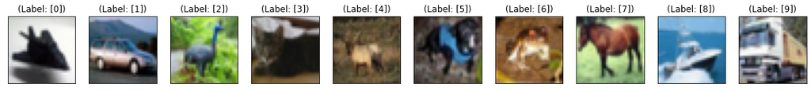

```python
plt.figure(figsize=(20, 4))

for i in range(10):
  idx = np.argwhere(y_train_cf == i)[0,0]
  ax = plt.subplot(2, 10, i + 1)
  # colormap = gray for better visualization
  plt.imshow(x_train_cf[idx])
  # add label title
  plt.title("(Label: " + str(y_train_cf[idx]) + ")")
  # remove axis from visualization
  ax.get_xaxis().set_visible(False)
  ax.get_yaxis().set_visible(False)
```

Le immagini sono a colori e riportano diversi tipi di animali e mezzi di trasporto, inoltre la visualizzazione è blurrata per tutte le immagini. Nello specifico le classi riportano immagini apparteneneti alle seguenti classi:

1. airplane
2. automobile
3. bird
4. cat
5. deer
6. dog
7. frog
8. horse
9. ship
10. truck

### Check Y label

Verifico che i valori delle label per verificare che siano coerenti e quindi compresi nel range $[0,9]$. Verifico inoltre che non ci sia un forte sbilanciamento tra le varie classi.

```python
print("Le label assumono i seguenti valori:", np.unique(y_train_cf))

# get the total number of labels
n_labels = len(np.unique(y_train_cf))
```

```
Le label assumono i seguenti valori: [0 1 2 3 4 5 6 7 8 9]
```

Le classi risultano essere nel range corretto, effettuerò però la conversione in one-hot encoding invece di mantenere dei numeri interi.

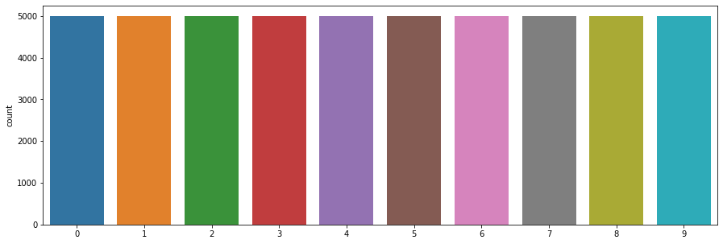

```python
plt.figure(figsize = (15,5))
sns.countplot(y_train_cf.reshape(len(y_train_cf)))
plt.show()
```

Il grafico non evidenzia sbilanciamenti.

### Preprocessing

In questa sezione mi occuperò di gestire le problematiche evidenziate dall'analisi del dataset in modo da ottenere un ''nuovo'' dataset pronto per essere passato al modello neurale. In particolare si effettuaranno i seguenti preprocessing:

1. Conversione dei valori in float e nell'intervallo $[0,1]$
2. One-hot encoding delle label (non obbligatorio per il modello).

Come nel caso precedente queste operazioni verranno effettuate sia sul training che sul test set, in modo da effettuare gli stesssi passaggi ed avere un test set coerente ed utilizzabile una volta trainato il modello. Inoltre si effettuerà lo stesso tipo di ragionamento sullo splitting del training set.

```python
# riscalo i valori in float in [0,1]
x_train_cf = x_train_cf.astype('float32')/255.0
x_test_cf = x_test_cf.astype('float32')/255.0

# verifico il risultato
print("Tipo dei valori dell'immagine: ", type(x_train_cf[0,10,12,0]))
```

```
Tipo dei valori dell'immagine:  <class 'numpy.float32'>
```

```python
# one hot encoding delle label
yc_train_cf = keras.utils.to_categorical(y_train_cf, n_labels)
yc_test_cf = keras.utils.to_categorical(y_test_cf, n_labels)

# visualizzo il risultato
print(y_train_cf[0], "to ->", yc_train_cf[0])
```

```
[6] to -> [0. 0. 0. 0. 0. 0. 1. 0. 0. 0.]
```

```python
# effettuo lo splitting del training set per ottenere una parte di validation
x_train_cf, x_val_cf, y_train_cf, y_val_cf = train_test_split(x_train_cf, yc_train_cf,
                                                              test_size = 0.1,
                                                              # per replicabilità
                                                              random_state=99)
```

### Neural network

Definisco la neural network per il task di classificazione seguendo le specifiche date per l'assignment. In particolare utilizzo le funzioni create in precedenza per costrutire e valutare il modello.  
In particolare in questo caso utilizzo già il modello con la funzione di ottimizzazione e con dropout rate migliore trovato rispettando l'architettura richiesta per l'esercizio.

```python
# definisco il modello
model_cf = create_neural_model(x_train_cf, "adam", dropout_rate=0.4)

# visualizzo il modello
print(model_cf.summary())
```

```
Model: "sequential_27"
_________________________________________________________________
 Layer (type)                Output Shape              Param #
=================================================================
 conv2d_162 (Conv2D)         (None, 30, 30, 32)        896

 activation_38 (Activation)  (None, 30, 30, 32)        0

 max_pooling2d_69 (MaxPoolin  (None, 15, 15, 32)       0
 g2D)

 flatten_25 (Flatten)        (None, 7200)              0

 dense_50 (Dense)            (None, 128)               921728

 activation_39 (Activation)  (None, 128)               0

 dropout_25 (Dropout)        (None, 128)               0

 dense_51 (Dense)            (None, 10)                1290

=================================================================
Total params: 923,914
Trainable params: 923,914
Non-trainable params: 0
_________________________________________________________________
None
```

```python
# traino il modello sui dati + validation set
# utilizzo lo stesso early stopping definito per il caso mnist
history_cf = model_cf.fit(x_train_cf, y_train_cf, epochs = 100,
                          batch_size = 128, verbose = 1,
                          shuffle = True, validation_data = (x_val_cf, y_val_cf),
                          callbacks = [early_stopping])
```

```
Epoch 00015: early stopping
```

Visualizzo alcune informazioni sul modello appena trainato e infine valuto le predizioni sul test set fatte sfruttando questo modello.

```python
print("Numero di epoche totali:", (early_stopping.stopped_epoch+1))
print("Epoca migliore (weights restored):", (early_stopping.best_epoch+1))
print("Accuracy training set all'epoca " + str(early_stopping.best_epoch+1) + ": "
      + str(history_cf.history['accuracy'][early_stopping.best_epoch]))
print("Accuracy validation set all'epoca " + str(early_stopping.best_epoch+1) + ": "
      + str(history_cf.history['val_accuracy'][early_stopping.best_epoch]))
print("Loss training set all'epoca " + str(early_stopping.best_epoch+1) + ": "
      + str(history_cf.history['loss'][early_stopping.best_epoch]))
print("Loss validation set all'epoca " + str(early_stopping.best_epoch+1) + ": "
      + str(history_cf.history['val_loss'][early_stopping.best_epoch]))
```

```
Numero di epoche totali: 15
Epoca migliore (weights restored): 13
Accuracy training set all'epoca 13: 0.6378222107887268
Accuracy validation set all'epoca 13: 0.6481999754905701
Loss training set all'epoca 13: 0.9982064962387085
Loss validation set all'epoca 13: 1.012116551399231
```

Visualizzo l'andamento dell'apprendimento del modello sia come loss che come accuracy. Anche in questo caso come per MNIST l'early stopping è stato fondamentale nel prevenire l'overfitting del modello.

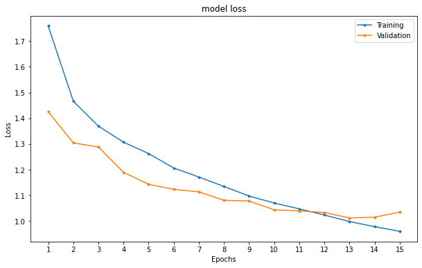

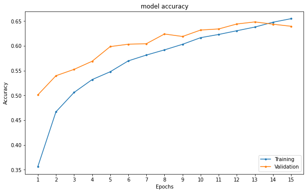

```python
plot_history(history_cf)
```

Come già anticipato questi risultati sono simili a quelli ottenuti sfruttando un maggior numero di epoche e anche cambiando funzione di ottimizzazione con ad esempio SGD o SGD+Momentum. Si è preferito mantenere questa configurazione in quanto le altre risultavano in un overfitting abbastanza pronunciato.  
Utilizzo quindi questo modello per effettuare le predizioni sul test set indipendente rispetto al validation set utilizzato durante il training.

### CIFAR10 prediction

```
Classification Report
               precision    recall  f1-score   support

           0       0.66      0.75      0.70      1000
           1       0.78      0.72      0.75      1000
           2       0.50      0.49      0.50      1000
           3       0.45      0.46      0.45      1000
           4       0.61      0.55      0.58      1000
           5       0.56      0.54      0.55      1000
           6       0.73      0.70      0.72      1000
           7       0.73      0.70      0.72      1000
           8       0.71      0.80      0.75      1000
           9       0.71      0.73      0.72      1000

    accuracy                           0.64     10000
   macro avg       0.64      0.64      0.64     10000
weighted avg       0.64      0.64      0.64     10000
```

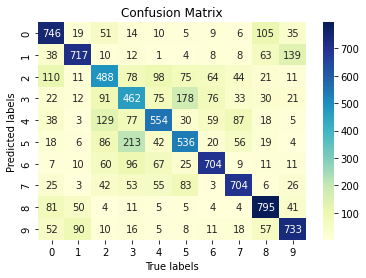

```python
# valuto le performance del modello
_, model_cf_cl = evaluate_predition_ffnn(model_cf, x_test_cf, yc_test_cf)
```

Il modello riesce ad ottenere le stesse performance ottenute con il validation set, tuttavia non sono particolarmente alte e sopratutto vi sono tanti errori nella classificazioni delle classi degli animali che vengono facilmente scambiati tra loro.

### Considerazioni sul modello

I risultati ottenuti sul dataset CIFAR10 sono nettamente peggiori rispetto a quelli ottenuti su MNIST con la stessa architettura. Questo è sicuramente dovuto alla maggior complessità del task di classificazione, ad esempio in questo caso le immagini sono *caratterizzate da colori* e all'interno della stessa categoria c'è *molta variabilità* come si può notare dall'esempio sottostante. Mentre nel dataset mnist la variabilità era molto più ridotta e cambiavano solo piccole porzioni delle immagini.

[figure not shown]

```python
plt.figure(figsize=(20, 4))

tmp = y_train_cf.argmax(axis = 1)
# get the first 10 image with label = 0
lst_idx = np.argwhere(tmp == 0)

for i in range(10):
  idx = lst_idx[i][0]
  ax = plt.subplot(2, 10, i + 1)
  # colormap = gray for better visualization
  plt.imshow(x_train_cf[idx])
  # add label title
  plt.title("(Label: " + str(tmp[idx]) + ")")
  # remove axis from visualization
  ax.get_xaxis().set_visible(False)
  ax.get_yaxis().set_visible(False)
```

### Second neural network

In questo caso cambiando semplicamente piccoli parametri dell'architettura non sembra possibile aumentare significativamente l'accuratezza del modello. Provo quindi a modificarla e a migliorarla rispetto al task di classificazione per il dataset CIFAR10. Dato che un possibile problema è la variabilità nelle immagini provo ad aggiungere dei layer di normalizzazione per provare a fixare questa problematica.  
Come base per la creazione del modello utilizzo *AlexNet e VGG* provo dunque a costruire degli stack di convoluzioni con dimensioni della finestra relativamente piccole, in questo modo cerco di non aumentare troppo il numero di parametri, dall'altro lato provo ad applicare la normalizzazione come avviene in AlexNet. Nei layer convoluzionali, tramite apposito parametro, sfrutto anche il padding per mantenere la dimensione dell'immagine originale.

```python
# per codice più snello
from keras import layers

model_cf_2 = keras.Sequential()

# padding=same per mantenere le dimensioni originali dell'immagine
model_cf_2.add(layers.Conv2D(32, (3,3), padding='same', activation='relu',
                             input_shape=x_train_cf.shape[1:]))
# applico la normalizzazione
model_cf_2.add(layers.BatchNormalization())
# Secondo layer convoluzionale del primo stack
model_cf_2.add(layers.Conv2D(32, (3,3), padding='same', activation='relu'))
# max pooling
model_cf_2.add(layers.MaxPooling2D(pool_size=(2,2)))
# applico la normalizzazione
model_cf_2.add(layers.BatchNormalization())

# Secondo stack convoluzionale con 64 filtri
model_cf_2.add(layers.Conv2D(64, (3,3), padding='same', activation='relu'))
# applico la normalizzazione
model_cf_2.add(layers.BatchNormalization())
model_cf_2.add(layers.Conv2D(64, (3,3), padding='same', activation='relu'))
# max pooling
model_cf_2.add(layers.MaxPooling2D(pool_size=(2,2)))
# applico la normalizzazione
model_cf_2.add(layers.BatchNormalization())

# terzo stack convoluzionale con 128 filtri
model_cf_2.add(layers.Conv2D(128, (3,3), padding='same', activation='relu'))
model_cf_2.add(layers.Conv2D(128, (3,3), padding='same', activation='relu'))
# applico la normalizzazione
model_cf_2.add(layers.BatchNormalization())
# max pooling
model_cf_2.add(layers.MaxPooling2D(pool_size=(2,2)))

# flattening
model_cf_2.add(layers.Flatten())
# Layer denso con dropout
model_cf_2.add(layers.Dense(64, activation='relu'))
model_cf_2.add(layers.Dropout(0.6))
model_cf_2.add(layers.Dense(n_labels, activation='softmax'))

# ottimizzatore della rete neurale
model_cf_2.compile(optimizer = "adam", loss = "categorical_crossentropy",
              metrics = ["accuracy"])
```

```python
print(model_cf_2.summary())
```

```
Model: "sequential_26"
_________________________________________________________________
 Layer (type)                Output Shape              Param #
=================================================================
 conv2d_156 (Conv2D)         (None, 32, 32, 32)        896

 batch_normalization_93 (Bat  (None, 32, 32, 32)       128
 chNormalization)

 conv2d_157 (Conv2D)         (None, 32, 32, 32)        9248

 max_pooling2d_66 (MaxPoolin  (None, 16, 16, 32)       0
 g2D)

 batch_normalization_94 (Bat  (None, 16, 16, 32)       128
 chNormalization)

 conv2d_158 (Conv2D)         (None, 16, 16, 64)        18496

 batch_normalization_95 (Bat  (None, 16, 16, 64)       256
 chNormalization)

 conv2d_159 (Conv2D)         (None, 16, 16, 64)        36928

 max_pooling2d_67 (MaxPoolin  (None, 8, 8, 64)         0
 g2D)

 batch_normalization_96 (Bat  (None, 8, 8, 64)         256
 chNormalization)

 conv2d_160 (Conv2D)         (None, 8, 8, 128)         73856

 conv2d_161 (Conv2D)         (None, 8, 8, 128)         147584

 batch_normalization_97 (Bat  (None, 8, 8, 128)        512
 chNormalization)

 max_pooling2d_68 (MaxPoolin  (None, 4, 4, 128)        0
 g2D)

 flatten_24 (Flatten)        (None, 2048)              0

 dense_48 (Dense)            (None, 64)                131136

 dropout_24 (Dropout)        (None, 64)                0

 dense_49 (Dense)            (None, 10)                650

=================================================================
Total params: 420,074
Trainable params: 419,434
Non-trainable params: 640
_________________________________________________________________
None
```

```python
# traino il modello sui dati + validation set
# utilizzo lo stesso early stopping definito per il caso mnist
history_cf_2 = model_cf_2.fit(x_train_cf, y_train_cf, epochs = 30,
                              batch_size = 64, verbose = 1, shuffle = True,
                              validation_data = (x_val_cf, y_val_cf),
                              callbacks = [early_stopping])
```

```
Epoch 00011: early stopping
```

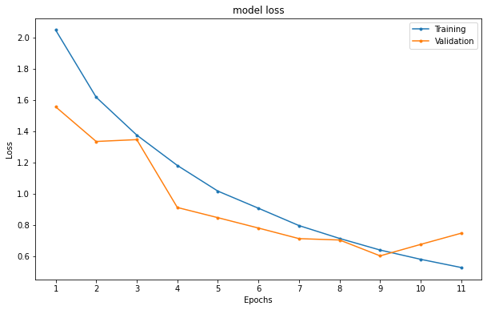

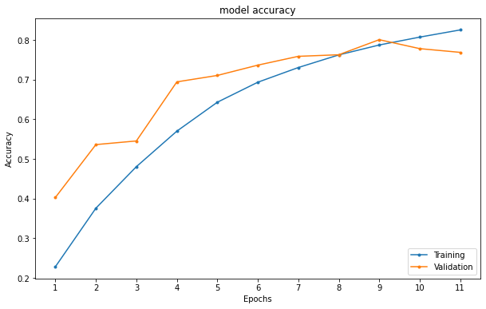

```python
# visualizzo la storia di training
plot_history(history_cf_2)
```

```
Classification Report
               precision    recall  f1-score   support

           0       0.76      0.82      0.79      1000
           1       0.92      0.88      0.90      1000
           2       0.71      0.66      0.68      1000
           3       0.56      0.66      0.61      1000
           4       0.85      0.70      0.77      1000
           5       0.79      0.62      0.69      1000
           6       0.84      0.83      0.84      1000
           7       0.80      0.87      0.83      1000
           8       0.86      0.91      0.89      1000
           9       0.82      0.91      0.86      1000

    accuracy                           0.79     10000
   macro avg       0.79      0.79      0.79     10000
weighted avg       0.79      0.79      0.79     10000
```

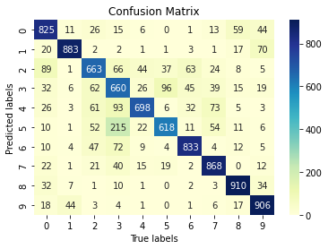

```python
# valutazione delle performance
_, model_cf_2_cl = evaluate_predition_ffnn(model_cf_2, x_test_cf, yc_test_cf)
```

Analizzando la matrice di confusione ed il report sulle singole label si nota che la classificazione ottiene *score molto alti nella maggior parte delle label*, i risultati più bassi si registrano infatti nella classificazione delle label $2$, $3$ e $5$ che riportano figure di uccelli, gatti e cani.

#### Considerazioni finali

Il modello così creato risulta essere migliore sia dal punto di vista delle **performance**, molto migliori rispetto a prima, sia dal punto di vista dei **parametri addestrabili** che è calato sensibilmente. In questo caso non è stato considerata la possibilità di effettuare il fine tuning da un modello pre-addestrato. Si riporta di seguito una stampa di confronto tra i due modelli proposti per i due parametri appena discussi.  
Nel confronto, per quanto evidenziato pocanzi sugli score delle singole label, utilizzo la misura della 'macro avg' che tiene conto degli score ottenuti su tutte la label così facendo non penalizzo nessuna classe.

```python
# salvo il numero di parametri
final_parms = np.sum([np.prod(v.shape) for v in model_cf_2.trainable_variables])
initial_parms = np.sum([np.prod(v.shape) for v in model_cf.trainable_variables])
# calcolo la differenza perfentuale tra il numero di parametri usati
diff = np.round(((final_parms-initial_parms)/initial_parms)*100,2)

print("Numero di parametri addestrabili primo modello:", initial_parms)
print("Numero di parametri addestrabili secondo modello:", final_parms)
print("Il secondo modello utilizza: " + str(diff) + "% di parametri rispetto al primo")
print("Macro-avg raggiunta dal primo modello:",
      str(np.round(model_cf_cl['macro avg']['precision'],2)))

print("Macro-avg raggiunta dal secondo modello:",
      str(np.round(model_cf_2_cl['macro avg']['precision'],2)))
```

```
Numero di parametri addestrabili primo modello: 923914
Numero di parametri addestrabili secondo modello: 419434
Il secondo modello utilizza: -54.6% di parametri rispetto al primo
Macro-avg raggiunta dal primo modello: 0.64
Macro-avg raggiunta dal secondo modello: 0.79
```

```python
# connesione a drive per produrre il file .html
from google.colab import drive
drive.mount('/content/drive')
```

```python
# download notebook in .html extension
%%shell
jupyter nbconvert --to html '/content/drive/MyDrive/Colab Notebooks/DigitalSignal/Assignment/Assignment4/DSIM_Assignment4.ipynb'
```

```
[NbConvertApp] Converting notebook /content/drive/MyDrive/Colab Notebooks/DigitalSignal/Assignment/Assignment4/DSIM_Assignment4.ipynb to html
[NbConvertApp] Writing 1144781 bytes to /content/drive/MyDrive/Colab Notebooks/DigitalSignal/Assignment/Assignment4/DSIM_Assignment4.html
```